# v1_exploration

Joan Claverol Romero

25/11/2019

```r
# libraries
if (require(pacman) == FALSE) {
  install.packages("pacman")
}
pacman::p_load(
  tidyverse, magrittr,
  # html tables creation,
  knitr, kableExtra,
  # visualization tools
  gridExtra,
  # text mining
  tm, SnowballC,
  # machine learning
  caret, modelr, randomForest
  )
# define themes for the plots
theme_set(theme_bw())
```

##### Inspiration

Find if we can predict the number of starts given by a user based on his review.

## 1st iteration

```r
reviews <- read_csv("../../data/raw/20190928-reviews.csv")
glimpse(reviews)
```

```
## Observations: 82,815
## Variables: 8
## $ asin         <chr> "B0000SX2UC", "B0000SX2UC", "B0000SX2UC", "B0000SX2UC", …
## $ name         <chr> "Janet", "Luke Wyatt", "Brooke", "amy m. teague", "trist…
## $ rating       <dbl> 3, 1, 5, 3, 4, 4, 5, 4, 5, 3, 4, 1, 2, 4, 1, 4, 5, 1, 5,…
## $ date         <chr> "October 11, 2005", "January 7, 2004", "December 30, 200…
## $ verified     <lgl> FALSE, FALSE, FALSE, FALSE, FALSE, FALSE, FALSE, FALSE, …
## $ title        <chr> "Def not best, but not worst", "Text Messaging Doesn't W…
## $ body         <chr> "I had the Samsung A600 for awhile which is absolute doo…
## $ helpfulVotes <dbl> 1, 17, 5, 1, 1, NA, 2, 2, 7, 3, 1, 4, 5, 1, NA, NA, NA, …
```

we will select only the reviews, title, and rating:

```r
kable(reviews %>%
    select(rating, title, body) %>%
    head(2)) %>%
  kable_styling(full_width = F, position = "center")
```

| rating | title | body |
| --- | --- | --- |
| 3 | Def not best, but not worst | I had the Samsung A600 for awhile which is absolute doo doo. You can read my review on it and detect my rage at the stupid thing. It finally died on me so I used this Nokia phone I bought in a garage … |
| 1 | Text Messaging Doesn’t Work | Due to a software issue between Nokia and Sprint this phone’s text messaging capabilities don’t work with Sprint’s system and won’t until a software patch comes out “some time in the next few months”.… |

How can I do a correct natural lenguage processing?

```r
# create an object with title reviews
reviews_title <- reviews %>%
  select(title)
# create an object with body reviews
reviews_body <- reviews %>%
  select(body) %>%
  head(1000)
```

Now we will clean the texts by defining the relevant words. We will start by analysing the *titles*. We need to create a *corpus* where we will clean it to create the bag of words:

```r
# function to clean a corpus
clean_corpus <- function(string, sparse) {
  # GOAL: transform a string to corpus, clean it, and return a tibble

  # check and load library tm (text mining)
  require(tm)

  # create the corpus
  corpus <- VCorpus(VectorSource(x = string))

  # put to lower all the variables
  corpus <- tm_map(x = corpus, FUN = content_transformer(tolower))

  # now we are going to eliminate any number inside the text
  corpus <- tm_map(x = corpus, FUN = removeNumbers)

  # we are going to elimiate puntuation signs
  corpus <- tm_map(x = corpus, FUN = removePunctuation)

  # remove articles
  corpus <- tm_map(corpus, FUN = removeWords, stopwords(kind = "en"))

  # we will apply the steaming to find the root word
  corpus <- tm_map(corpus, FUN = stemDocument)

  # eliminate extra spaces
  corpus <- tm_map(corpus, FUN = stripWhitespace)

  # using the corpus, we are going to build the "bag of words"
  dtm <- DocumentTermMatrix(x = corpus)

  # now we will reduce the words that appear few times, in order ro reduce its
  # sparsity
  dtm <- removeSparseTerms(x = dtm, sparse = sparse) # we keep the 999% of most frequent
  # words

  # we will transform it as a dataframe
  dataset <- as_tibble(as.matrix(dtm))

  # return the corpus
  return(dataset)
}

# apply the function to review titles
dataset <- clean_corpus(string = reviews_title$title, sparse = 0.999)
```

Now we are goinig to apply a classification algorithm to predict the rating the user has given. The best algorithms we can use are:

- Decition trees
- Naive Bayes
- Sometimes SVM

Let’s add the rating inside our new dataframe. Our model will try to predict the seniment of the review:

- Bad: 1 or 2 stars
- Neutral: 3 stars
- Good: 4 or 5 stars

Let’s addthe rating variable:

```r
# add the ratings
dataset %<>%
  mutate(rating = reviews$rating,
         rating = if_else(rating %in% c("1","2"), "Bad",
                          if_else(rating == "3", "Neutral","Good")),
         rating = factor(rating, levels = c("Bad","Neutral","Good"))) %>%
  select(-`don’t`, -`function`) # exclude variables
```

Now we can run the model, in that case a Random Forest. First let’s create de data partition:

```r
# create a data partition
set.seed(42)
train_id <- createDataPartition(y = dataset$rating,
                                p = 0.75,
                                list = F)
train <- dataset[train_id,]
test <- dataset[-train_id,]
```

Now run the model:

```r
# run a random forest
# set.seed()
mod_rf <- randomForest(rating ~ .,
                       data = train,
                       ntree = 10)
```

Let’s check our model results:

1. General metrics

Train:

```r
kable(postResample(pred = predict(mod_rf, train), obs = train$rating)) %>%
  kable_styling(full_width = F)
```

|  | x |
| --- | --- |
| Accuracy | 0.8474047 |
| Kappa | 0.6534318 |

Test:

```r
kable(postResample(pred = predict(mod_rf, test), obs = test$rating)) %>%
  kable_styling(full_width = F)
```

|  | x |
| --- | --- |
| Accuracy | 0.8112834 |
| Kappa | 0.5700607 |

2. Confusion matrix testing

Results on the testing:

```r
caret::confusionMatrix(factor(test$rating), reference = predict(mod_rf, test),
                       dnn = c("Prediction","Reference"))
```

```
## Confusion Matrix and Statistics
##
##           Reference
## Prediction   Bad Neutral  Good
##    Bad      3686      42  1606
##    Neutral   484     203   752
##    Good      968      55 12907
##
## Overall Statistics
##
##                Accuracy : 0.8113
##                  95% CI : (0.8059, 0.8166)
##     No Information Rate : 0.7373
##     P-Value [Acc > NIR] : < 2.2e-16
##
##                   Kappa : 0.5701
##
##  Mcnemar's Test P-Value : < 2.2e-16
##
## Statistics by Class:
##
##                      Class: Bad Class: Neutral Class: Good
## Sensitivity              0.7174       0.676667      0.8455
## Specificity              0.8941       0.939421      0.8119
## Pos Pred Value           0.6910       0.141070      0.9266
## Neg Pred Value           0.9055       0.994965      0.6519
## Prevalence               0.2482       0.014491      0.7373
## Detection Rate           0.1780       0.009805      0.6234
## Detection Prevalence     0.2576       0.069507      0.6728
## Balanced Accuracy        0.8058       0.808044      0.8287
```

Which are our main predictors?

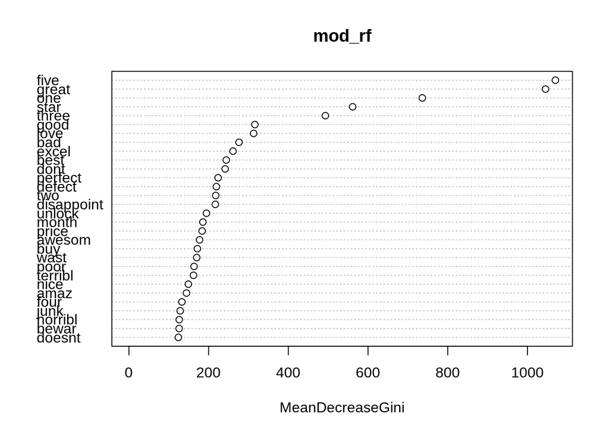

```r
randomForest::varImpPlot(mod_rf)
```

## Notes and exploration

```r
items <- read_csv("../../data/raw/20190928-items.csv",
                  col_types = cols(
                    prices = col_number()
                  ))
glimpse(items)
```

```
## Observations: 792
## Variables: 9
## $ asin         <chr> "B0000SX2UC", "B0009N5L7K", "B000SKTZ0S", "B00198M12M", …
## $ brand        <chr> "Nokia", "Motorola", "Motorola", "Nokia", "Motorola", "M…
## $ title        <chr> "Dual-Band / Tri-Mode Sprint PCS Phone w/ Voice Activate…
## $ url          <chr> "https://www.amazon.com/Dual-Band-Tri-Mode-Activated-Dia…
## $ image        <chr> "https://m.media-amazon.com/images/I/2143EBQ210L._AC_UY2…
## $ rating       <dbl> 3.0, 2.9, 2.6, 2.4, 3.3, 3.2, 2.0, 2.7, 3.2, 3.5, 2.9, 2…
## $ reviewUrl    <chr> "https://www.amazon.com/product-reviews/B0000SX2UC", "ht…
## $ totalReviews <dbl> 14, 7, 22, 5, 21, 12, 1, 3, 8, 133, 2, 18, 201, 76, 131,…
## $ prices       <dbl> NA, 49.95, NA, NA, NA, NA, 78.99, NA, 99.99, 59.89, 99.9…
```

Notes from items data set:

- Check unique ASIN
- Maybe check typs of brands
- Rating? Internal reference? Info Kaggle: Product Avg. Rating. Maybe the number of stars
- Total number of review maybe has some correlation with prices. Easy to check
- **Main goal. Can I predict the prices by using the information like the rating Avg., the number of total reviews and maybe some other info**?

```r
reviews <- read_csv("../../data/raw/20190928-reviews.csv")
glimpse(reviews)
```

```
## Observations: 82,815
## Variables: 8
## $ asin         <chr> "B0000SX2UC", "B0000SX2UC", "B0000SX2UC", "B0000SX2UC", …
## $ name         <chr> "Janet", "Luke Wyatt", "Brooke", "amy m. teague", "trist…
## $ rating       <dbl> 3, 1, 5, 3, 4, 4, 5, 4, 5, 3, 4, 1, 2, 4, 1, 4, 5, 1, 5,…
## $ date         <chr> "October 11, 2005", "January 7, 2004", "December 30, 200…
## $ verified     <lgl> FALSE, FALSE, FALSE, FALSE, FALSE, FALSE, FALSE, FALSE, …
## $ title        <chr> "Def not best, but not worst", "Text Messaging Doesn't W…
## $ body         <chr> "I had the Samsung A600 for awhile which is absolute doo…
## $ helpfulVotes <dbl> 1, 17, 5, 1, 1, NA, 2, 2, 7, 3, 1, 4, 5, 1, NA, NA, NA, …
```

Notes:

- Merge information using ASIN code
- Can I found bots or other problems based on names? Maybe a specific client that comments a lot
- rating of starts from 1 to 5
- dates can give us some information?? Find high moment of sells. Extra work to properly format the dates
- verified? Maybe a good validator to check for bots
- title analysis. Relevant after to know the number of starts]
- description of the botes. Sentiment analysis? Structure? can we predict the number of starts added based on the comments? Maybe we will have to use the information as helpful votes.
- Validation of the community by using helpful votes.

A quick idea would be to create a model to predict the price based on the items data:

# Price distribution

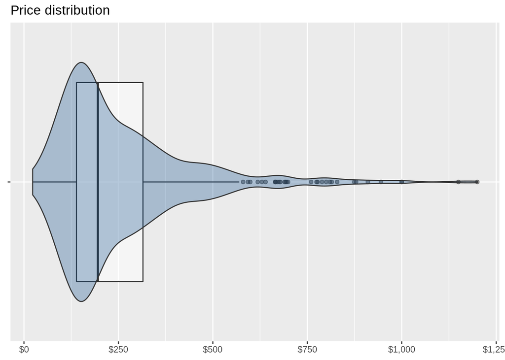

```r
items %>%
  drop_na(prices) %>%
  ggplot(aes(x = "", y = prices)) +
    geom_boxplot(alpha = 0.5) +
    geom_violin(fill = "dodgerblue4", alpha = 0.3) +
    scale_y_continuous(labels = scales::dollar) +
    coord_flip() +
    labs(title = "Price distribution") +
    theme(
      axis.title = element_blank()
    )
```

## Clustering items

Of the information we see, there are some clear outlies with a bigger price than > $500. Maybe we can create a cluster of premium phones. Even that, the distribution is positive skewed.

Maybe we can create three categories here:

- Low_price : 0 to 250$
- Medium_price: 250 to 450$
- High_price: > 450$

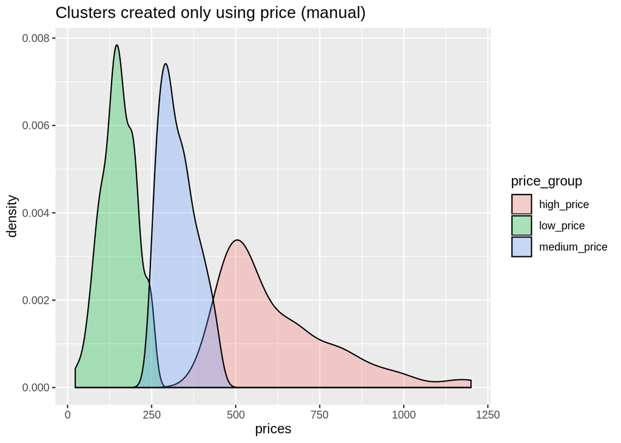

```r
items %<>%
  mutate(price_group = if_else(between(prices, 0, 250), "low_price",
                               if_else(between(prices, 250, 450), "medium_price",
                                       if_else(prices > 450, "high_price",
                                               "unknown_price"))),
         price_group = if_else(is.na(price_group), "unknown_price", price_group)
    ) %>%
  rownames_to_column(var = "id")
p_manual_cl <- items %>%
  filter(!is.na(price_group)) %>%
  ggplot(aes(x = prices, fill = price_group)) +
    geom_density(alpha = 0.3) +
    labs(title = "Clusters created only using price (manual)")
p_manual_cl
```

Another way to create clusters will be by using k-means, and we can also introduce the information from number of ratings and total reviews.

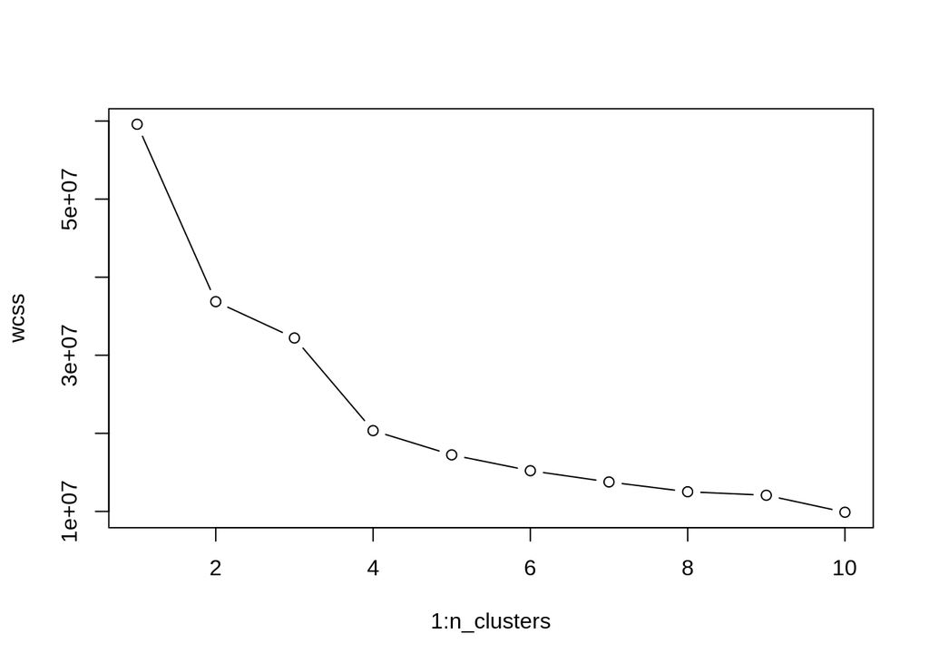

```r
# select numerical variables and id, and drop allmissing values
items_cl <- items %>%
  select(prices, rating, totalReviews, id) %>% #rating, totalReviews,
  drop_na(prices)

# find the right number of clusters
set.seed(123)
wcss <- vector()
n_clusters <- 10 # define the number of clusters we want to use
for (i in 1:n_clusters) {
  wcss[i] <- sum(kmeans(x = items_cl, centers = i)$withinss)
}
plot(x = 1:n_clusters, y = wcss, type = "b")
```

Using the elbow technique, we can see that 4 clusters is a good a number of clusters for this data.

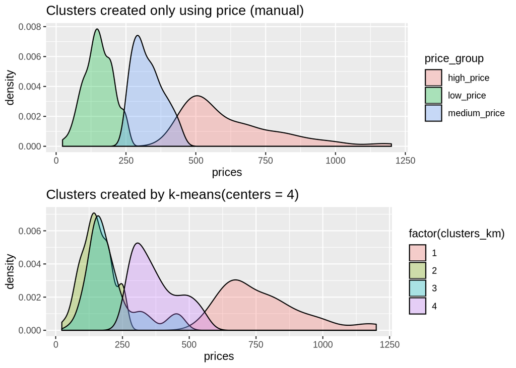

```r
# us of k means to create 3 clusters of information
set.seed(123)
n_cl <- 4 # define decided number of clusers
clusters <- kmeans(x = items_cl %>%
                     select(-id),
                   centers = n_cl)

# add the 3 clusters inside the items data
items <- items_cl %>%
  mutate(clusters_km = clusters$cluster) %>%
  right_join(y = items %>% select(-prices, -rating, -totalReviews),
             by = "id")
rm(clusters) # remove created clusters

# visualize if the clusters has the same distribution that the manual clusters
# we created
p_kmeans_cl <- items %>%
  filter(!is.na(price_group)) %>%
  ggplot(aes(x = prices, fill = factor(clusters_km))) +
    geom_density(alpha = 0.3) +
    labs(title = paste0("Clusters created by k-means(centers = ", n_cl ,")"))
grid.arrange(p_manual_cl, p_kmeans_cl)
```

We can also use a dendograms for hierarchical:

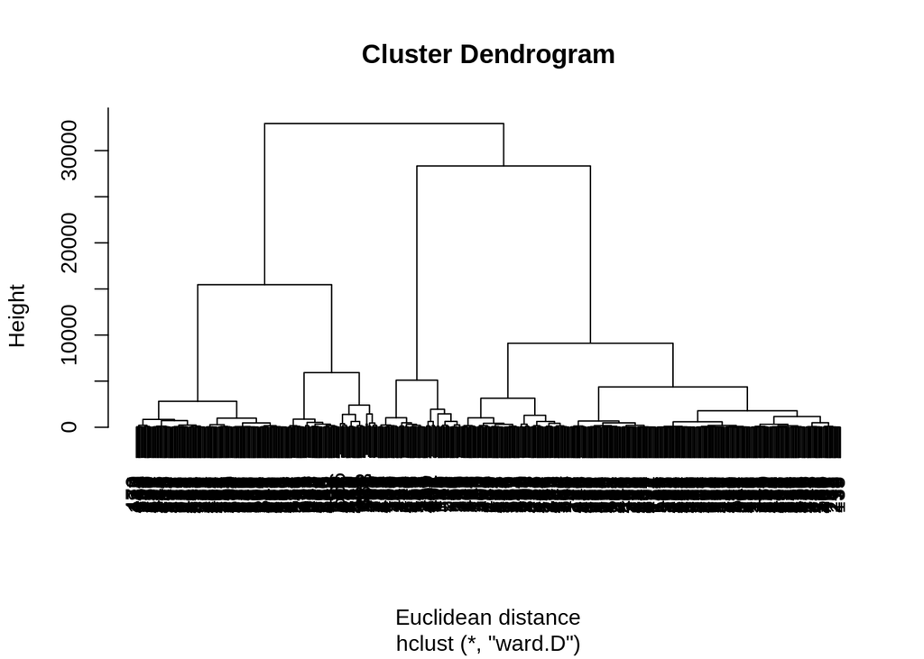

```r
dendogram <- hclust(dist(x = items_cl %>% select(-id),
                         method = "euclidean"), # we will use euclidean distance
                    method = "ward.D")
plot(dendogram, xlab = "Euclidean distance")
```

If we decide to cut by the longuer vercial lign, avoiding to cut any hortizontal lign, we can see the number of clusters will be 4, the same than kmeans. Let’s see if they represent the same groups.

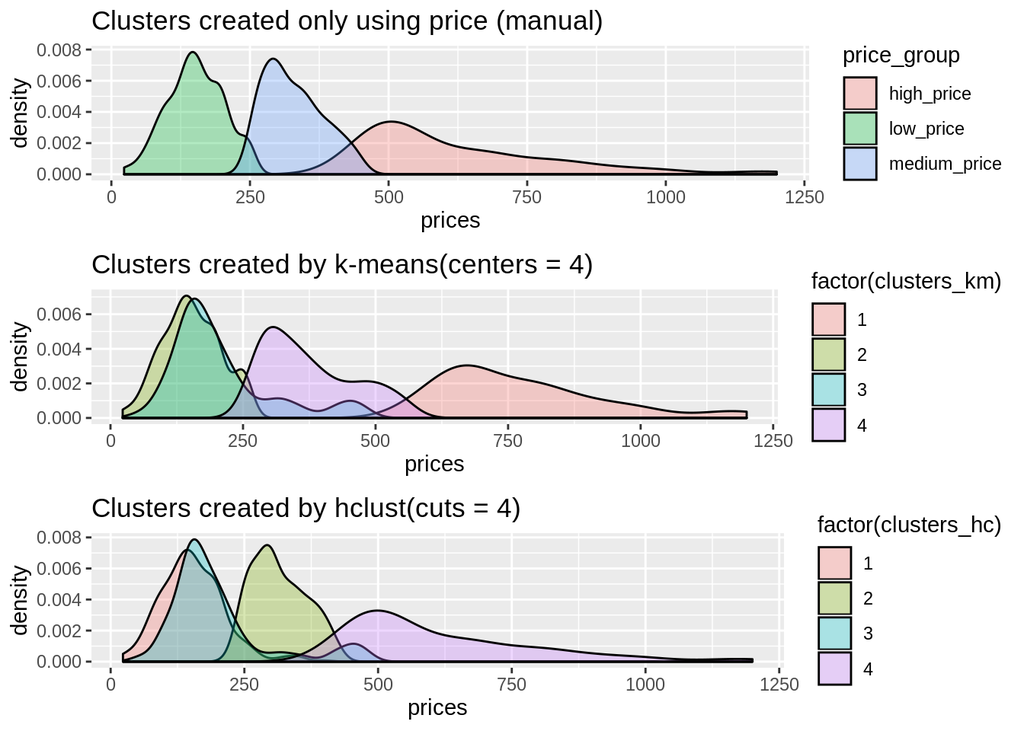

```r
# define where to cut the tree (dendogram)
k <- 4
# add the new groups inside the data
items <- items_cl %>%
  mutate(clusters_hc = cutree(tree = dendogram, k = k)) %>%
  right_join(y = items %>% select(-prices, -rating, -totalReviews),
             by = "id")

rm(dendogram) # remove created clusters

# visualize if the clusters has the same distribution that the manual clusters
# we created
p_hc_cl <- items %>%
  filter(!is.na(price_group)) %>%
  ggplot(aes(x = prices, fill = factor(clusters_hc))) +
    geom_density(alpha = 0.3) +
    labs(title = paste0("Clusters created by hclust(cuts = ", k ,")"))
grid.arrange(p_manual_cl, p_kmeans_cl, p_hc_cl)
```

The hierachy approach is closer to the hypothesis we created by hand, where we defined 3 groups of prices.

### Right formats of the dates